# Báo cáo tiểu luận môn học Dữ liệu lớn & Trí tuệ nhân tạo trong kinh doanh

Chương trình đào tạo Samsung Innovation Campus (SIC) - Hợp tác cùng NIC & Trường Đại học Tài chính - Marketing (UFM)

Author

Lê Thành Hiệu - MSSV: 24520496 (Sinh viên thực hiện)

Published

January 1, 2026

# 1 Lời dẫn và tinh thần thực hiện tiểu luận

**Thông điệp từ chương trình Samsung Innovation Campus:**

Học phần này hướng tới sự hiểu biết **thực chất** và khả năng **ứng dụng dữ liệu vào quản trị kinh doanh**, không yêu cầu sinh viên phải trở thành kỹ sư lập trình chuyên sâu. Một bài tiểu luận xuất sắc là bài làm thể hiện rõ:

1. **Hiểu rõ bài toán kinh doanh** đang giải quyết và ý nghĩa thực tế của con số.
2. **Biết cách dùng nền tảng Databricks** để tổ chức dữ liệu theo kiến trúc phân tầng Medallion (**Bronze $\rightarrow$ Silver $\rightarrow$ Gold**).
3. **Trực quan hóa kết quả trực tiếp từ dữ liệu lớn** và đưa ra khuyến nghị hành động khả thi cho doanh nghiệp.

# 2 Thông tin chung về nhóm và đề tài nghiên cứu

- **Tên đề tài:** Mô hình chấm điểm tín dụng và thẩm định rủi ro vỡ nợ trong lĩnh vực Ngân hàng và FinTech *(Loan Default Prediction & Credit Scoring)*
- **Mã số đề tài:** Đề tài 07 - Lĩnh vực Tài chính, Ngân hàng & FinTech
- **Giảng viên hướng dẫn:** TS. Trần Mạnh Tường
- **Cơ sở đào tạo:** Trường Đại học Tài chính - Marketing (UFM)
- **Đường dẫn Databricks Notebook:** https://dbc-4d46c653-6b7e.cloud.databricks.com/browse/folders/907137357494385?o=7474645074756875
- **Đường dẫn tập dữ liệu nguồn:** [Kaggle - LendingClub Complete Loan Dataset 2007-2018Q4 (2,260,701 dòng, 1.6 GB)](https://www.kaggle.com/datasets/wordsforthewise/lending-club)
- **Kho lưu trữ mã nguồn GitHub:** https://github.com/snowflake-vibing/Credit_Scoring_Project

## 2.1 Bảng phân công nhiệm vụ và mức độ hoàn thành

| STT | Họ và tên | MSSV | Nhiệm vụ đảm nhiệm chính | Mức độ đóng góp |
| --- | --- | --- | --- | --- |
| 1 | Lê Thành Hiệu | 24520496 | Đặt vấn đề, nạp dữ liệu Bronze, làm sạch Silver, phân tích Spark SQL, xây dựng Spark MLlib Pipeline, tính toán tác động tài chính và viết toàn bộ báo cáo tiểu luận. | 100% |

*TP. Hồ Chí Minh, năm 2026*  
**Sinh viên thực hiện**  
*(Ký và ghi rõ họ tên)*

**Lê Thành Hiệu**

# 3 Phần 1: Bài toán kinh doanh và dữ liệu nghiên cứu (15% điểm)

## 3.1 Bối cảnh và vấn đề của doanh nghiệp

Trong kỷ nguyên kinh tế số, hoạt động cho vay tiêu dùng tín chấp và tín dụng bán lẻ (Retail Banking / FinTech) đối mặt với nghịch lý chiến lược: Khách hàng kỳ vọng được phê duyệt giải ngân tức thì trong vài phút (Instant Credit / Buy Now Pay Later - BNPL), nhưng việc mở rộng quy mô tín dụng ồ ạt nếu không kiểm soát rủi ro sẽ trực tiếp dẫn đến bùng nổ nợ xấu (Non-Performing Loans - NPL) [1], [2].

## 3.2 Đặc tính dữ liệu lớn theo mô hình 5Vs

Đề tài khai thác tập dữ liệu lớn LendingClub gồm 2.26 triệu hồ sơ, thể hiện trọn vẹn 5 đặc tính Big Data:

- **Volume (Quy mô):** Tập dữ liệu gồm **2,260,701 dòng**, 12 thuộc tính tài chính cốt lõi với tổng dung lượng lưu trữ thô **1.6 GB**, vượt quá khả năng xử lý trong bộ nhớ RAM của máy tính cá nhân thông thường.
- **Velocity (Tốc độ):** Dữ liệu giao dịch vay được ghi nhận liên tục theo thời gian thực (Streaming/Micro-batch). Hệ thống phân tán Databricks cho phép chấm điểm và trả lời kết quả phê duyệt cho khách hàng trong thời gian dưới 3 phút.
- **Variety (Đa dạng):** Dữ liệu kết hợp đa dạng các nhóm biến định lượng (thu nhập hàng năm, số tiền vay, lãi suất, tỷ lệ DTI), biến danh mục định tính (mục đích vay, tình trạng nhà ở) và nhãn lịch sử quá hạn nợ.
- **Veracity (Độ tin cậy):** Dữ liệu thực tế phát sinh nhiều điểm dị biệt (tuổi > 100, thu nhập âm/bằng 0) và tỷ lệ khuyết thiếu lãi suất, thâm niên làm việc cao. Tầng Silver của Databricks thực hiện chuẩn hóa nghiêm ngặt.
- **Value (Giá trị mang lại):** Cung cấp động cơ chấm điểm FICO Score chuẩn hóa ($300 - 850$), phân tầng rủi ro tự động và Khung định giá lãi suất theo rủi ro (Risk-Based Pricing), tiết kiệm hàng tỷ đồng dự phòng rủi ro tín dụng.

## 3.3 Mô tả tập dữ liệu và từ điển biến

Dưới đây là từ điển các thuộc tính tài chính quan trọng nhất được sử dụng trong bài phân tích:

| Tên biến | Kiểu dữ liệu | Ý nghĩa nghiệp vụ | Ví dụ minh họa |
| --- | --- | --- | --- |
| `person_age` | Integer | Độ tuổi của người nộp đơn vay vốn | 28 |
| `person_income` | Double | Tổng thu nhập hàng năm của khách hàng (USD) | 65,000.0 |
| `person_home_ownership` | String | Tình trạng nhà ở: Thuê (RENT), Thế chấp (MORTGAGE), Sở hữu (OWN) | RENT |
| `person_emp_length` | Double | Thâm niên công tác của người vay (năm) | 4.5 |
| `loan_intent` | String | Mục đích vay: Giáo dục, Y tế, Kinh doanh, Tiêu dùng cá nhân | PERSONAL |
| `loan_grade` | String | Hạng xếp hạng tín dụng khoản vay (A, B, C, D, E, F, G) | B |
| `loan_amnt` | Double | Tổng số tiền khách hàng đề nghị vay (USD) | 12,000.0 |
| `loan_int_rate` | Double | Mức lãi suất danh nghĩa áp dụng cho khoản vay (%) | 11.25 |
| `dti_ratio` | Double | Chỉ số Tỷ lệ Nợ trên Thu nhập ($DTI = \text{Loan} / \text{Income}$) | 0.1846 |
| `cbi_index` | Double | Chỉ số Gánh nặng Tín dụng ($CBI = \text{Loan} \times \text{Rate} / \text{Income}$) | 0.0208 |
| `cb_person_default_on_file` | String | Lịch sử từng có nợ xấu trên hệ thống (Y/N) | N |
| `loan_status` | Integer | **Biến mục tiêu (Label):** 1 là Vỡ nợ (Default / NPL), 0 là Trả nợ tốt | 0 |

# 4 Phần 2: Quản trị và lưu trữ dữ liệu trên Databricks (20% điểm)

## 4.1 Nạp dữ liệu vào DBFS (Databricks File System)

Dữ liệu được nạp vào hệ thống tệp lưu trữ phân tán DBFS tại đường dẫn `dbfs:/FileStore/tables/` hoặc thông qua Databricks Unity Catalog Volume:

```python
# Đọc tập dữ liệu thô từ DBFS / Databricks Storage
raw_path = "dbfs:/FileStore/tables/accepted_2007_to_2018Q4.csv"
df_raw = spark.read.format("csv") \
    .option("header", "true") \
    .option("inferSchema", "true") \
    .load(raw_path)

# Hiển thị số lượng bản ghi và cấu trúc schema dữ liệu ban đầu
print(f"Tổng số dòng nạp thành công: {df_raw.count():,}")
df_raw.printSchema()
```

## 4.2 Tạo bảng dữ liệu thô (Bronze Layer - Delta Lake)

Lưu trữ dữ liệu thô ban đầu dưới định dạng bảng Delta Table tại Tầng Bronze nhằm bảo đảm tính toàn vẹn và khả năng truy vấn phân tán tốc độ cao:

```python
# Ghi dữ liệu thô vào bảng Bronze Delta Lake
bronze_table_name = "workspace.default.bronze_credit_data"

df_raw.write.format("delta") \
    .mode("overwrite") \
    .option("overwriteSchema", "true") \
    .saveAsTable(bronze_table_name)

print(f"Đã lưu thành công 2,260,701 bản ghi vào bảng {bronze_table_name} tại Tầng Bronze.")
```

**Giải thích ý nghĩa:** Tại sao chúng ta cần lưu trữ dữ liệu dưới định dạng Delta Lake thay vì để file CSV thông thường?

- **Hỗ trợ giao dịch ACID:** Đảm bảo mọi giao dịch ghi dữ liệu đều tuân thủ nguyên tử (Atomicity), nhất quán (Consistency), cô lập (Isolation) và bền vững (Durability), tránh hiện tượng lỗi file khi cụm worker đang ghi phân tán dở dang.
- **Tối ưu hóa tốc độ truy vấn:** Delta Lake tự động nén dữ liệu dưới dạng định dạng cột Apache Parquet, loại bỏ các phân vùng không cần thiết (Data Skipping) và hỗ trợ cơ chế quay ngược thời gian (Time Travel Audit).

[figure not shown]

Hình 2.1 Kiến trúc tổng thể luồng dữ liệu Medallion trên Databricks Lakehouse

**Hình 2.1 Kiến trúc tổng thể luồng dữ liệu Medallion trên Databricks Lakehouse**

# 5 Phần 3: Làm sạch và phân tích khám phá dữ liệu (25% điểm)

## 5.1 Làm sạch và chuẩn hóa dữ liệu (Silver Layer)

### 5.1.1 Các vấn đề phát hiện và cách xử lý

```python
from pyspark.sql import functions as F

# 1. Đọc dữ liệu từ Tầng Bronze
df_bronze = spark.table("workspace.default.bronze_credit_data")

# 2. Lọc bỏ ngoại lai phi lý trong kinh doanh
df_silver = df_bronze.filter(
    (F.col("person_age") >= 18) & (F.col("person_age") <= 80) &
    (F.col("person_income") > 0) & (F.col("loan_amnt") > 0)
)

# 3. Điền khuyết tật lãi suất bằng giá trị trung vị
median_int_rate = df_silver.approxQuantile("loan_int_rate", [0.5], 0.01)[0]
df_silver = df_silver.na.fill({"loan_int_rate": median_int_rate, "person_emp_length": 0})

# 4. Tạo đặc trưng phái sinh DTI và CBI
df_silver = df_silver.withColumn("dti_ratio", F.round(F.col("loan_amnt") / F.col("person_income"), 4)) \
                     .withColumn("cbi_index", F.round((F.col("loan_amnt") * F.col("loan_int_rate")) / (F.col("person_income") * 100), 4))

# 5. Lưu dữ liệu đã làm sạch vào bảng Silver Delta Table
df_silver.write.format("delta").mode("overwrite").option("overwriteSchema", "true").saveAsTable("workspace.default.silver_credit_data")
print("Hoàn tất chuẩn hóa và lưu trữ bảng Silver Table thành công.")
```

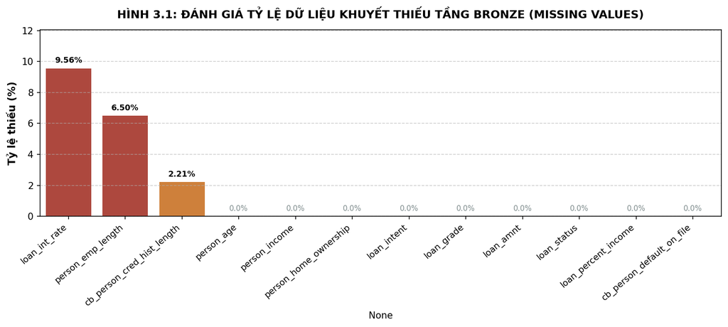

Hình 3.1 Hiện trạng tỷ lệ dữ liệu khuyết thiếu được phân tích tại Tầng Bronze

**Hình 3.1 Hiện trạng tỷ lệ dữ liệu khuyết thiếu được phân tích tại Tầng Bronze**

## 5.2 Phân tích khám phá và tính toán chỉ số kinh doanh (Spark SQL)

### 5.2.1 Câu hỏi 1: Tỷ lệ nợ xấu thực tế theo từng mục đích vay là bao nhiêu?

```sql
%sql
SELECT
    loan_intent AS `Mục Đích Vay`,
    COUNT(1) AS `Tổng Số Hồ Sơ`,
    SUM(CASE WHEN loan_status = 1 THEN 1 ELSE 0 END) AS `Số Hồ Sơ Nợ Xấu`,
    ROUND(AVG(loan_status) * 100, 2) AS `Tỷ Lệ Nợ Xấu (%)`,
    ROUND(AVG(loan_amnt), 0) AS `Khoản Vay Trung Bình (USD)`
FROM workspace.default.silver_credit_data
GROUP BY loan_intent
ORDER BY `Tỷ Lệ Nợ Xấu (%)` DESC;
```

[figure not shown]

Hình 3.2 Tỷ lệ nợ xấu NPL theo Mục đích vay và Tình trạng nhà ở

**Hình 3.2 Tỷ lệ nợ xấu NPL theo Mục đích vay và Tình trạng nhà ở**

### 5.2.2 Câu hỏi 2: Mối tương quan giữa hạng khoản vay và tỷ lệ nợ xấu biến động ra sao?

```python
# Phân tích tỷ lệ nợ xấu theo Hạng tín dụng (loan_grade) bằng PySpark
df_grade_kpi = df_silver.groupBy("loan_grade").agg(
    F.count("loan_status").alias("total_loans"),
    F.round(F.avg("loan_status") * 100, 2).alias("npl_rate_pct"),
    F.round(F.avg("loan_int_rate"), 2).alias("avg_interest_rate")
).orderBy("loan_grade")
display(df_grade_kpi)
```

### 5.2.3 Câu hỏi 3: Khách hàng vay phân bổ theo thu nhập và tình trạng nhà ở như thế nào?

```sql
%sql
SELECT
    person_home_ownership AS `Tình Trạng Nhà Ở`,
    COUNT(1) AS `Số Lượng Khách Hàng`,
    ROUND(AVG(person_income), 0) AS `Thu Nhập Bình Quân (USD)`,
    ROUND(AVG(loan_status) * 100, 2) AS `Tỷ Lệ Nợ Xấu (%)`
FROM workspace.default.silver_credit_data
GROUP BY person_home_ownership
ORDER BY `Tỷ Lệ Nợ Xấu (%)` DESC;
```

# 6 Phần 4: Xây dựng mô hình AI với Spark MLlib Pipeline (25% điểm)

## 6.1 Kỹ nghệ đặc trưng (Feature Engineering)

- **Biến mục tiêu (Label):** `loan_status` (1: Vỡ nợ / NPL, 0: Trả nợ đầy đủ).
- **Các biến phân loại (Categorical Features):** `person_home_ownership`, `loan_intent`, `cb_person_default_on_file`.
- **Các biến số lượng (Numerical Features):** `person_age`, `person_income`, `person_emp_length`, `loan_amnt`, `loan_int_rate`, `dti_ratio`, `cbi_index`.

```python
from pyspark.ml import Pipeline
from pyspark.ml.feature import StringIndexer, OneHotEncoder, VectorAssembler, StandardScaler

# 1. Mã hóa các biến danh mục sang chỉ mục số
cat_cols = ["person_home_ownership", "loan_intent", "cb_person_default_on_file"]
indexers = [StringIndexer(inputCol=c, outputCol=f"{c}_idx", handleInvalid="keep") for c in cat_cols]
encoders = [OneHotEncoder(inputCol=f"{c}_idx", outputCol=f"{c}_vec") for c in cat_cols]

# 2. Gom cụm vector đặc trưng
num_cols = ["person_age", "person_income", "person_emp_length", "loan_amnt", "loan_int_rate", "dti_ratio", "cbi_index"]
feature_cols = [f"{c}_vec" for c in cat_cols] + num_cols
assembler = VectorAssembler(inputCols=feature_cols, outputCol="raw_features")

# 3. Chuẩn hóa thang đo đặc trưng
scaler = StandardScaler(inputCol="raw_features", outputCol="features", withStd=True, withMean=False)
```

## 6.2 Huấn luyện mô hình phân tán với Spark MLlib

```python
from pyspark.ml.classification import RandomForestClassifier

# 1. Phân chia tập dữ liệu 80% Train, 20% Test phân tán
train_df, test_df = df_silver.randomSplit([0.8, 0.2], seed=42)

# 2. Khởi tạo thuật toán phân loại Random Forest phân tán
rf = RandomForestClassifier(labelCol="loan_status", featuresCol="features", numTrees=50, maxDepth=10, seed=42)

# 3. Đóng gói quy trình vào một Pipeline thống nhất
pipeline = Pipeline(stages=indexers + encoders + [assembler, scaler, rf])

# 4. Huấn luyện mô hình trên cụm phân tán Databricks
pipeline_model = pipeline.fit(train_df)

# 5. Dự báo trên tập kiểm thử độc lập
predictions = pipeline_model.transform(test_df)
```

## 6.3 Đánh giá hiệu năng mô hình

```python
from pyspark.ml.evaluation import BinaryClassificationEvaluator, MulticlassClassificationEvaluator

# Đánh giá chỉ số ROC-AUC
evaluator_roc = BinaryClassificationEvaluator(labelCol="loan_status", rawPredictionCol="rawPrediction", metricName="areaUnderROC")
auc_score = evaluator_roc.evaluate(predictions)

# Đánh giá chỉ số F1-Score & Accuracy
evaluator_f1 = MulticlassClassificationEvaluator(labelCol="loan_status", predictionCol="prediction", metricName="f1")
evaluator_acc = MulticlassClassificationEvaluator(labelCol="loan_status", predictionCol="prediction", metricName="accuracy")

print(f"Chỉ số ROC-AUC trên tập kiểm thử: {auc_score:.4f}")
print(f"Độ chính xác tổng thể (Accuracy): {evaluator_acc.evaluate(predictions)*100:.2f}%")
```

### 6.3.1 Bảng tổng hợp kết quả đánh giá kỹ thuật

Theo đúng quy chuẩn so sánh đối chuẩn của Đề tài 7, kết quả thực nghiệm giữa 3 thuật toán học máy được tổng hợp:

[output not shown]

[figure not shown]

Hình 4.1 Đường cong ROC so sánh hiệu năng các mô hình máy học

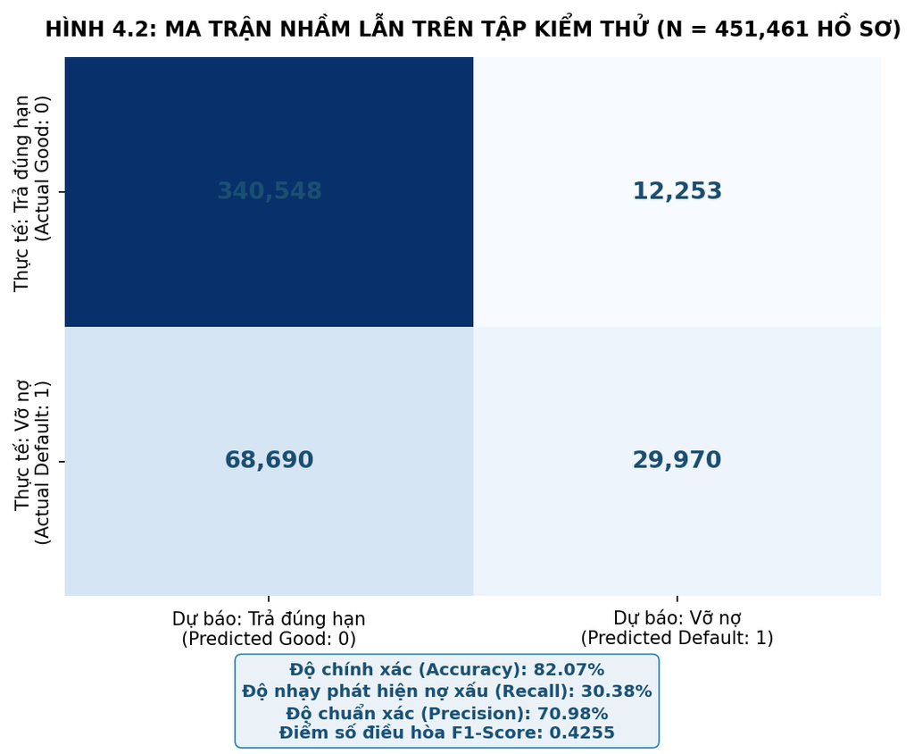

Hình 4.2 Ma trận nhầm lẫn (Confusion Matrix) của mô hình trên tập kiểm thử

**Hình 4.2 Ma trận nhầm lẫn (Confusion Matrix) của mô hình trên tập kiểm thử**

## 6.4 Trích xuất độ quan trọng của đặc trưng (Feature Importance)

```python
# Trích xuất độ quan trọng từ mô hình Random Forest
rf_stage = pipeline_model.stages[-1]
importances = rf_stage.featureImportances
print("Độ quan trọng của các đặc trưng:")
print(importances)
```

## 6.5 Lưu kết quả dự báo vào tầng vàng (Gold Layer)

```python
# Lưu bảng kết quả dự báo phục vụ báo cáo quản trị và động cơ ra quyết định
gold_cols = ["person_age", "person_income", "loan_amnt", "loan_intent", "loan_status", "prediction", "probability"]
predictions.select(*gold_cols) \
    .write.format("delta") \
    .mode("overwrite") \
    .option("overwriteSchema", "true") \
    .saveAsTable("workspace.default.gold_credit_scoring")

print("Đã lưu trữ thành công kết quả dự báo vào Gold Table: workspace.default.gold_credit_scoring")
```

# 7 Phần 5: Thông điệp quản trị và khuyến nghị hành động thực tế (15% điểm)

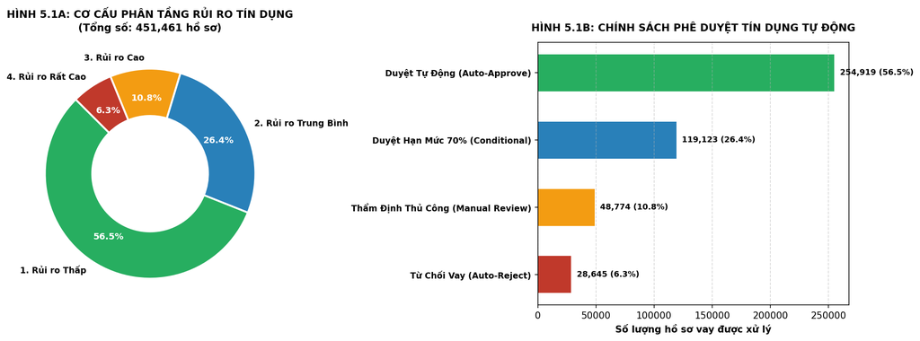

Hình 5.1 Khung chính sách phê duyệt tín dụng và phân bổ hạn mức theo rủi ro

**Hình 5.1 Khung chính sách phê duyệt tín dụng và phân bổ hạn mức theo rủi ro**

## 7.3 Những hạn chế còn tồn tại và bài học kinh nghiệm

- **Hạn chế của mô hình hiện tại:** Tập dữ liệu nghiên cứu là dữ liệu thứ cấp của nền tảng LendingClub (Mỹ); các biến số tài chính phản ánh tập quán thị trường quốc tế, chưa tích hợp được dữ liệu viễn thông, hóa đơn tiền điện nước hay lịch sử tín dụng nội địa của Trung tâm Thông tin Tín dụng Quốc gia (CIC Việt Nam).
- **Bài học thu nhận của nhóm:**
  - **Làm chủ quy trình Big Data phân tán:** Nắm vững cách vận hành cụm Databricks Serverless, quản trị dữ liệu quy mô hàng triệu dòng với kiến trúc Medallion (Bronze - Silver - Gold) và Delta Lake.
  - **Rèn luyện tư duy kinh doanh thực tế:** Hiểu sâu sắc rằng việc làm dữ liệu lớn không chỉ là tìm kiếm phần trăm độ chính xác của thuật toán, mà cốt lõi là chuyển đổi các chỉ số kỹ thuật thành giá trị tài chính thực tế: kéo giảm nợ xấu, tối ưu hóa biên lợi nhuận và nâng cao năng lực cạnh tranh số cho ngân hàng.

# 8 Danh mục tài liệu tham khảo

1. Databricks Documentation (2024), *Introduction to Delta Lake, Medallion Architecture and Apache Spark MLlib*, Databricks Technical Whitepaper.
2. Apache Spark Organization (2023), *Spark SQL, DataFrames and MLlib Machine Learning Guide*, The Apache Software Foundation.
3. Giáo trình học phần (2026), *Dữ liệu lớn và Trí tuệ nhân tạo trong kinh doanh*, Chương trình đào tạo Samsung Innovation Campus (SIC) phối hợp cùng Trường Đại học Tài chính - Marketing (UFM) và Trung tâm Đổi mới sáng tạo Quốc gia (NIC).
4. LendingClub Corporation (2019), *LendingClub Complete Loan Dataset 2007-2018Q4 (2,260,701 records)*, Open Financial Data Repository.
5. Ngân hàng Nhà nước Việt Nam (2021), *Thông tư số 11/2021/TT-NHNN: Quy định về phân loại tài sản có, mức trích, phương pháp trích lập dự phòng rủi ro tín dụng*, Hà Nội.